# MLBA Lab 1 - Setup

MLBA Tools & Lab Setup

Ilia Azizi

02.03.2026

## Objectives

- Learn about vesion-control, Git & GitHub
- Use R and Rstudio
- Learn about virtual environments in R to ensure reproducibility.
- Learn about using python 🐍 in (and with) R. This is useful for some ML lab sessions, and cutting-edge ML is often first implemented in python.

## Git & GitHub for Collaboration

- **What is Git?** Git is a version-control system that helps track changes, collaborate on projects, and revert to previous versions of a file.
- **What is GitHub?** GitHub provides a cloud-based hosting service that lets you manage Git repositories.
- **Git vs. GitHub:** Git is a version-control technology to manage source code history, while GitHub is only one of the hosting service for Git repositories.

[figure not shown]

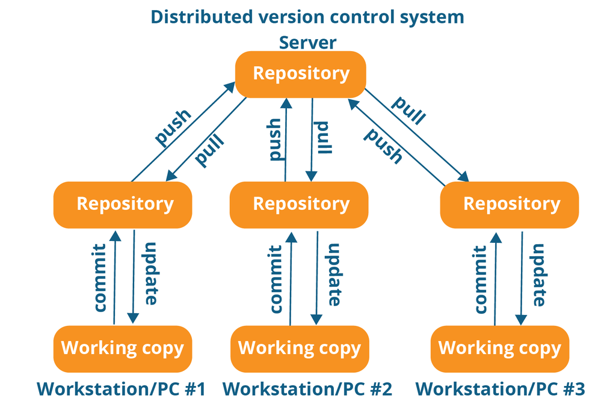

## Creating a Repository on GitHub

1. Navigate to [GitHub](https://github.com/new) and create a new repository.
2. Choose a name and description for your repository.
3. Select whether the repository is public or private.
4. Click “Create repository.”

[figure not shown]

*Install [GitHub Desktop app](https://desktop.github.com/) to help you with using GitHub. Additionally, you can see our [FAQ](https://do-unil.github.io/mlba/faq.html#how-do-i-ask-a-question-or-report-an-issue-or-suggestion-regarding-the-content) for obtaining professional accounts.*

[figure not shown]

[figure not shown]

## GitHub Workflow

- **Cloning a Repository with GitHub Desktop**
  1. Open GitHub Desktop and clone the repository to your local machine.
  2. This creates a local copy of the repository for work and synchronization.
- **Committing Changes**
  1. Make changes to your files in the project directory.
  2. Use GitHub Desktop to commit these changes, adding a meaningful commit message.
- **Push and Pull Changes**
  1. Push your committed changes to GitHub to share with collaborators.
  2. Pull changes made by others to keep your local repository up to date.

## Using RStudio Projects

- RStudio projects simplify the management of R soure code.
- Use the [here](https://here.r-lib.org/) package for easy file path management within projects.

[interactive chart not shown]

## Virtual environments in R (`renv`)

#### The What & The Why

- **`renv`** is a package management tool that helps you manage the packages used in an R project.
- Ensures that your project is reproducible.
- Provides a consistent environment by isolating the packages used in your project.
- Simplifies installation and setup.
- Helps you avoid compatibility issues.
- Makes it easy to share your work with others.

## Virtual environments in R (`renv`)

#### The How

1. Create a new **`renv`** project with `renv::init()`.
2. `renv::restore()` to install packages from the `renv.lock` file.
3. Use `renv::snapshot()` to occasionally update your packages.
4. Use `renv::status()` to see if the list in `renv.lock` needs updating.

## Python 🐍 in R (`reticulate`)

### Small Motivation

- Python is arguably more demanded in machine learning than R.
- Widely-used language in the industry.
- Powerful libraries for data manipulation, analysis, and modeling.
- Relatively easy to pick up even for beginners to programming.
- Combining the strengths of both R and Python can enhance your skills.

## Python 🐍 in R (`reticulate`)

### Configuration

1. Install `reticulate` package in R.
2. Use `reticulate::use_python()` or `reticulate::use_condaenv()` to specify the location of your python environment.

```r
library(reticulate)
use_condaenv("MLBA")
py_config()
```

3. Use `reticulate::import()` to import python modules in R.

```r
pd <- import("pandas")
```

4. Use `reticulate::py_run_string()` to execute python code in R.

```r
py_run_string("x = 3; y = 4; print('The sum of x and y is:', x + y)")
```

```
#> The sum of x and y is: 7
```

## Running Python code in R

- To run Python code in R, use `{python}` at the beginning of the code chunk.

````markdown
```{python}
my_dict = {'a' : 3, 'b' : 5, 'c' : 6}
```
````

- To access R objects in Python, use `r.OBJECT_NAME`.

````markdown
```{r}
my_list <- list(a = 1, b = 2, c = 3)
```
````

````markdown
```{python}
print(r.my_list['b'])
```
````

- To access Python objects in R, use `py$OBJECT_NAME`.

````markdown
```{r}
print(py$my_dict$b)
```
````

## Object casting in Python & R

- Use `reticulate::r_to_py()` and `reticulate::py_to_r()` to explicitly change between objects.

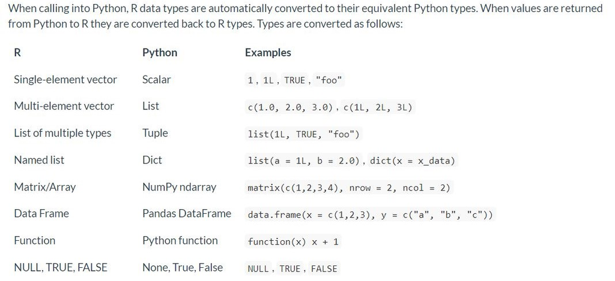

## Example: Plotting with R & Python

```
Load some data
```

```r
## load mtcars dataset
data(mtcars)
```

```
Plotting with base R
```

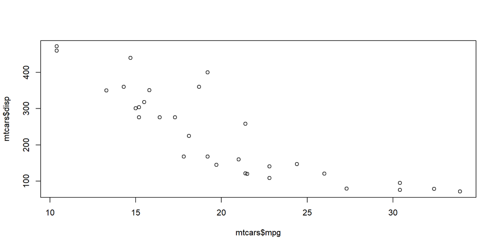

```r
# Using base R plot
plot(mtcars$mpg, mtcars$disp)
```

```
Plotting by using python within R
```

```r
# Using `matplotlib`
plt <- reticulate::import("matplotlib.pyplot")
plt$scatter(mtcars$mpg, mtcars$disp)
plt$xlabel("mpg", fontsize = 12)
plt$ylabel("disp", fontsize = 12)
```

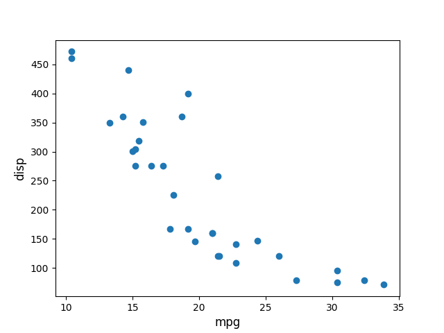

## Example: Regression in R & Python

- Loading data
- R
- Python
- Python within R

```
Loading the data R
```

```r
# load the data in R
data(iris)
# exclude the `species` column (we
# focus on regression here)
iris <- select(iris, -"Species")
head(iris)
```

```
#>   Sepal.Length Sepal.Width Petal.Length Petal.Width
#> 1          5.1         3.5          1.4         0.2
#> 2          4.9         3.0          1.4         0.2
#> 3          4.7         3.2          1.3         0.2
#> 4          4.6         3.1          1.5         0.2
#> 5          5.0         3.6          1.4         0.2
#> 6          5.4         3.9          1.7         0.4
```

```
Modelling in pure R
```

```r
# example of running a model on iris
# data
r_lm <- lm("Sepal.Length ~. ", data = iris)
summary(r_lm)
```

```
#>
#> Call:
#> lm(formula = "Sepal.Length ~. ", data = iris)
#>
#> Residuals:
#>      Min       1Q   Median       3Q      Max
#> -0.82816 -0.21989  0.01875  0.19709  0.84570
#>
#> Coefficients:
#>              Estimate Std. Error t value Pr(>|t|)
#> (Intercept)   1.85600    0.25078   7.401 9.85e-12 ***
#> Sepal.Width   0.65084    0.06665   9.765  < 2e-16 ***
#> Petal.Length  0.70913    0.05672  12.502  < 2e-16 ***
#> Petal.Width  -0.55648    0.12755  -4.363 2.41e-05 ***
#> ---
#> Signif. codes:  0 '***' 0.001 '**' 0.01 '*' 0.05 '.' 0.1 ' ' 1
#>
#> Residual standard error: 0.3145 on 146 degrees of freedom
#> Multiple R-squared:  0.8586, Adjusted R-squared:  0.8557
#> F-statistic: 295.5 on 3 and 146 DF,  p-value: < 2.2e-16
```

```
Modelling in pure Python
```

```
#>                             OLS Regression Results
#> ==============================================================================
#> Dep. Variable:           Sepal.Length   R-squared:                       0.859
#> Model:                            OLS   Adj. R-squared:                  0.856
#> Method:                 Least Squares   F-statistic:                     295.5
#> Date:              dim., 01 mars 2026   Prob (F-statistic):           8.59e-62
#> Time:                        16:28:03   Log-Likelihood:                -37.321
#> No. Observations:                 150   AIC:                             82.64
#> Df Residuals:                     146   BIC:                             94.69
#> Df Model:                           3
#> Covariance Type:            nonrobust
#> ================================================================================
#>                    coef    std err          t      P>|t|      [0.025      0.975]
#> --------------------------------------------------------------------------------
#> const            1.8560      0.251      7.401      0.000       1.360       2.352
#> Sepal.Width      0.6508      0.067      9.765      0.000       0.519       0.783
#> Petal.Length     0.7091      0.057     12.502      0.000       0.597       0.821
#> Petal.Width     -0.5565      0.128     -4.363      0.000      -0.809      -0.304
#> ==============================================================================
#> Omnibus:                        0.345   Durbin-Watson:                   2.060
#> Prob(Omnibus):                  0.842   Jarque-Bera (JB):                0.504
#> Skew:                           0.007   Prob(JB):                        0.777
#> Kurtosis:                       2.716   Cond. No.                         54.7
#> ==============================================================================
#>
#> Notes:
#> [1] Standard Errors assume that the covariance matrix of the errors is correctly specified.
```

[figure not shown]

```python
# load the required libraries
import statsmodels.api as sm
import pandas as pd
# Fit linear regression model to iris coming from R
X = r.iris[['Sepal.Width','Petal.Length','Petal.Width']]
y = r.iris['Sepal.Length']
X = sm.add_constant(X)
py_lm_fit = sm.OLS(y, X).fit()
#print regression results
print(py_lm_fit.summary())
```

```
Modelling in R with Python libraries
```

```r
# load the library
sm <- import("statsmodels.api")
# model the data
py_lm <- sm$OLS(dplyr::pull(iris, "Sepal.Length"),
    dplyr::select(iris, -"Sepal.Length"))
# fit the data
py_lm_fit <- py_lm$fit()
# print the summary
print(py_lm_fit$summary())
```

```
#> <class 'statsmodels.iolib.summary.Summary'>
#> """
#>                                  OLS Regression Results
#> =======================================================================================
#> Dep. Variable:                      y   R-squared (uncentered):                   0.996
#> Model:                            OLS   Adj. R-squared (uncentered):              0.996
#> Method:                 Least Squares   F-statistic:                          1.284e+04
#> Date:              dim., 01 mars 2026   Prob (F-statistic):                   1.33e-177
#> Time:                        16:28:03   Log-Likelihood:                         -61.215
#> No. Observations:                 150   AIC:                                      128.4
#> Df Residuals:                     147   BIC:                                      137.5
#> Df Model:                           3
#> Covariance Type:            nonrobust
#> ================================================================================
#>                    coef    std err          t      P>|t|      [0.025      0.975]
#> --------------------------------------------------------------------------------
#> Sepal.Width      1.1211      0.024     47.658      0.000       1.075       1.168
#> Petal.Length     0.9235      0.057     16.205      0.000       0.811       1.036
#> Petal.Width     -0.8957      0.139     -6.439      0.000      -1.171      -0.621
#> ==============================================================================
#> Omnibus:                        0.421   Durbin-Watson:                   2.007
#> Prob(Omnibus):                  0.810   Jarque-Bera (JB):                0.570
#> Skew:                           0.026   Prob(JB):                        0.752
#> Kurtosis:                       2.703   Cond. No.                         26.0
#> ==============================================================================
#>
#> Notes:
#> [1] R² is computed without centering (uncentered) since the model does not contain a constant.
#> [2] Standard Errors assume that the covariance matrix of the errors is correctly specified.
#> """
```

## Conclusion

- `renv` helps with managing packages in R, ensuring reproducibility, and making your work easier to share.
- `reticulate` allows you to use python in R and combine the strengths of both languages.
- Learning these tools will help you become more effective in machine learning.
- Let’s get started with the lab exercises!

# Thank You for your attention!

Questions?